# MaineDMR Predicated Lobster Fishing Effort/Catch

Bill DeVoe

9/21/2020

# Introduction

Effort and catch data for the Maine lobster fishery is mostly lacking in spatial resolution; data reported to the Maine Department of Marine Resources via 10% mandatory harvester reporting has only included the lobster zone and the distance from shore, binned to the categories 0-3NM, 3-12NM, and 12+ NM. Mapping effort and catch based on these attributes produces spatial representations with approximately a half decimal degree coverage, as shown below.

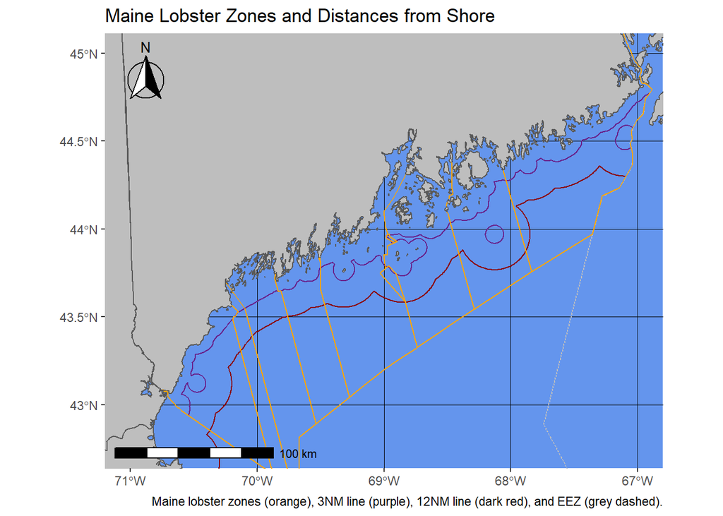

While future reporting requirements will include additional spatial reporting requirements, data provided to the department at this time can only be mapped at this scale.

Harvester reports also include a single attribute for depth fished, indicating the average depth fished during a trip. Reported depths have shown considerable quality issues, including improbable or impossible depths. Attempts to further increase the spatial resolution of produced map products using depth data have created maps with features at scales smaller than the source data would support. Additionally, gaps in reported depths in the source data have created inconsistencies in the produced map not reflective of actual fishing distributions. Therefore, reported depth was not used in this analysis.

# Data Sources

Harvester and dealer report data for 2016-2018 were provided by the DMR Landings program. Each report represented a single lobster trips. Dealer reports represent all trips for each year, while harvester reports represent a 10% selection of harvesters per zone.

The following attributes from the harvester and dealer reports were used:

Attributes from dealer and harvester reports utilized in this analysis.

| Field Name | Dealer Report | Harvester Report | Type | Description |
| --- | --- | --- | --- | --- |
| year | Yes | Yes | Integer | Year of the report. |
| quarter | Yes | Yes | Integer | Quarter of the report, floor of the month divided by 3. |
| zone | Yes | Yes | Character | Lobster zone the report occurred within, letters A through G. |
| dist_from_shore | No | Yes | Integer | The distance from shore in nautical miles of the harvester report, coded as 0: 0-3NM, 3: 3-12NM, and 12: 12+ NM |
| depth_m | No | Yes | Numeric | Depth reported by the harvester in meters, average of the minimum and maximum depths reported for the trip. |
| pounds | Yes | Yes | Numeric | The weight of lobsters landed in the trip in pounds, as represented by the harvester or dealer report. |
| value | Yes | Yes | Numeric | The value of lobsters landed in the trip in US dollars, as represented by the harvester or dealer report. |
| sf | Yes | Yes | Character | Flag for State or Federal fishery. |

# Catch Apportioning Methods

Total trips and landings for each zone/distance area were estimated by apportioning dealer data to each area based on the ratios of harvester reports for each area to the totals per zone. All processing was done in `R 4.0.0`, relying heavily on the [tidyverse](https://www.tidyverse.org/) packages for table manipulation and [sf](https://r-spatial.github.io/sf/index.html) (Simple Features) package for manipulating spatial data.

## Preprocessing

Harvester and dealer data were filtered to remove a small number of erroneous records. The following filtering was used:

### Harvester Data

- Removed VTR records where the latitude and longitude provided placed them in a zone overlap area.
- Removed reports that were flagged as State fishery but reported a distance from shore > 3 nautical miles.
- Removed records where fishery was unknown.
- Removed records where zone and distance from shore were `NULL` or `NK`.

### Dealer data

- Removed records where zone was `NULL` or `NK`.
- Removed records where fishery was unknown.

## Basic Apportioning

Quarterly catch and trip count were apportioned for each zone/distance area based on the simple equation:

$$pounds = \frac{area\_lbs\_h}{qtr\_lbs\_h}*{qtr\_lbs\_d}$$

Where:

- ${area\_lbs\_h}$ was the sum quarterly harvester reported landings for that zone/distance area.
- ${qtr\_lbs\_h}$ was the sum harvester reported landings for the quarter for the lobster zone.
- ${qtr\_lbs\_d}$ was the sum dealer reported landings for the quarter for the lobster zone.

This same methodology was utilized to apportion trips to each area.

## Zone Overlap Extrapolation

Maine lobster zones overlap in several areas. The largest overlap occurs between zones F and G in Southern Maine, with smaller overlaps occurring between zones C and D as well as E and D. A map of these overlaps is shown below.

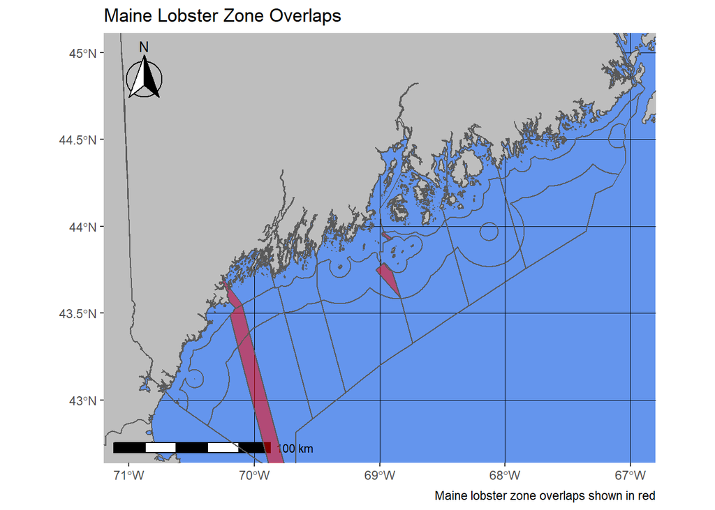

For each zone/distance area bordering an overlap, an adjustment factor was calculated based on the following formula:

$$adj\_factor =
\frac{overlap\_sq\_m}{area\_sq\_m + overlap\_sq\_m} \$$

Where:

- ${overlap\_sq\_m}$ was the geographic area in square meters of the overlap.
- ${area\_sq\_m}$ was the geographic area in square meters of the adjacent zone/distance area.

The adjustment factor was then used to redistribute trips and catch. For zone/distance areas adjacent to an overlap, catch was deducted from the area’s total. Within each zone overlap, the adjustment factor was used to add the deducted portion of the adjacent areas catch to the overlap. As each overlap bordered two zones, this calculation was performed twice per overlap area. The resulting totals were thus grouped on zone/distance and summed. The following formula demonsrates this logic, which was also used to extrapolate trips within the zone overlaps:

$$adj\_pounds =
\begin{cases}
{pounds} - ({pounds} * {adj\_factor}) &, \text{ if area is adjacent to an overlap} \\
{pounds} * {adj\_factor} &, \text{ if area is within an overlap} \\
{pounds} &, \text{ else area is not bordering or within an overlap} \\
\end{cases}$$
Where:

- ${pounds}$ was the apportioned catch for the zone/distance area (or adjacent area for overlaps).
- ${adj\_factor}$ was the previously calculated adjustment factor for each area.

## Quality Control

Final totals were compared against the source dealer data to check that no trips or catch were lost during the apportioning. The sum of the trips and catch in the final product was equal to the sum of trips and catch in the source dealer data.

# Map Product

The final map product is provided in GeoPackage and GeoJSON format. Both formats were used as they can be read by nearly any GIS system and avoids many of the issues create by ESRI Shape Files, most notably the 10 character limit on field names which would truncate many of the field names within this product.

## Spatial Representation

- `Native Storage Format`: Simple Features, GeoPackage
- `Geometry Type`: vector multi-polygon
- `Projections`:
  - [EPSG 26919](https://spatialreference.org/ref/epsg/26919/) (GeoPackage format),
  - [EPSG 4326](https://spatialreference.org/ref/epsg/4326/) (GeoJSON format),
- `Total Number of Unique Features`: 24
- `ISO Topic Categories`: oceans, environment, biota

## Numeric Precision

All numeric fields were rounded to the nearest whole integer.

## Data Fields

Description of fields provided in lobster catch map layer.

| Field Name | Type | Description |
| --- | --- | --- |
| zone | Character | Lobster zone, A to G including overlaps. |
| dist_from_shore | Character | Distance from shore band in nautical miles, as text description. |
| area_km2 | Numeric | Area of the feature in square kilometers, as calculated in the UTM Zone 19N CRS. |
| id | Character | Unique identifier for each feature, formed by concaternation of the zone and distance from shore codes into a hyphen-delimited string. |
| trips_q1_federal | Numeric | First quarter trips in the federal fishery, meaned 2016-2018. |
| trips_q1_state | Numeric | First quarter trips in the state fishery, meaned 2016-2018. |
| trips_q2_federal | Numeric | Second quarter trips in the federal fishery, meaned 2016-2018. |
| trips_q2_state | Numeric | Second quarter trips in the state fishery, meaned 2016-2018. |
| trips_q3_federal | Numeric | Third quarter trips in the federal fishery, meaned 2016-2018. |
| trips_q3_state | Numeric | Third quarter trips in the state fishery, meaned 2016-2018. |
| trips_q4_federal | Numeric | Fourth quarter trips in the federal fishery, meaned 2016-2018. |
| trips_q4_state | Numeric | Fourth quarter trips in the state fishery, meaned 2016-2018. |
| pounds_q1_federal | Numeric | First quarter landings in pounds in the federal fishery, meaned 2016-2018. |
| pounds_q1_state | Numeric | First quarter landings in pounds in the state fishery, meaned 2016-2018. |
| pounds_q2_federal | Numeric | Second quarter landings in pounds in the federal fishery, meaned 2016-2018. |
| pounds_q2_state | Numeric | Second quarter landings in pounds in the state fishery, meaned 2016-2018. |
| pounds_q3_federal | Numeric | Third quarter landings in pounds in the federal fishery, meaned 2016-2018. |
| pounds_q3_state | Numeric | Third quarter landings in pounds in the state fishery, meaned 2016-2018. |
| pounds_q4_federal | Numeric | Fourth quarter landings in pounds in the federal fishery, meaned 2016-2018. |
| pounds_q4_state | Numeric | Fourth quarter landings in pounds in the state fishery, meaned 2016-2018. |
| total_trips_federal | Numeric | Total annual federal trips, meaned 2016-2018. |
| total_trips_state | Numeric | Total annual state trips, meaned 2016-2018. |
| total_pounds_federal | Numeric | Total annual federal landings in pounds, meaned 2016-2018. |
| total_pounds_state | Numeric | Total annual state landings in pounds, meaned 2016-2018. |
| total_trips | Numeric | Total annual trips, meaned 2016-2018. |
| total_pounds | Numeric | Total annual landings in pounds, meaned 2016-2018. |
| geom | Geometry(MultiPolygon) | Polygon geometry. |